# BIOS 6624: Project 3

Ryan Summers

2026-04-01

## Load Data

```r
fmhst_raw <- read_csv("/Users/ryan_summers/Library/Mobile Documents/com~apple~CloudDocs/GitHub/BIOS6624-Class/Project3/DataRaw/frmgham2.csv")
```

## Data Management & Cleanup

Remove subjects who had event (stroke) at baseline and Filter to 10yrs cutoff. Calculate censored indicator if event doesn’t happen within 10yrs and calculate time to censoring variable.

```r
cutoff_days <- 10*365.25

fmhst_filt <- fmhst_raw %>%
  # remove subjects who had event prior to baseline assessment
  filter(PERIOD == 1, PREVSTRK == 0) %>%   # baseline cohort
  mutate(
    # time to event or being censored truncated at 10 years
    TIMESTRKorCENS_10y = pmin(TIMESTRK, cutoff_days),

    # event indicator within 10 years
    STROKE_10y = if_else(STROKE == 1 & TIMESTRK <= cutoff_days, 1, 0),

    ## all censored subjects
    ## **TIMESTRK includes censored participants if STROKE==0**
    CENSORED_10y = if_else(STROKE_10y == 0, 1, 0),

    # convert variables to factors
    SEX = factor(SEX, levels = c(1,2), labels = c("Men", "Women")),
    DIABETES = factor(DIABETES, levels = c(0,1), labels = c("No", "Yes")),
    PREVCHD = factor(PREVCHD, levels = c(0,1), labels = c("No", "Yes")),
    BPMEDS = factor(BPMEDS, levels = c(0,1), labels = c("No", "Yes")),
    CURSMOKE = factor(CURSMOKE, levels = c(0,1), labels = c("No", "Yes")),
    STROKE_10y = factor(STROKE_10y, levels = c(0,1), labels = c("No-Censored", "Yes")),
    STROKE_bin = ifelse(STROKE_10y == "Yes", 1, 0),
    CENSORED_10y = factor(CENSORED_10y, levels = c(0, 1), labels = c("No", "Yes")),
    TIMESTRKorCENS_10y_yrs = TIMESTRKorCENS_10y/365.25,
    ) %>%
  mutate(
    SYSBP_10 = SYSBP / 10,
    TOTCHOL_10 = TOTCHOL / 10)
```

## Exploratory Data Analysis (EDA)

### Table1

```r
tbl1 <- fmhst_filt %>%
  tbl_summary(
    by = SEX,
    include = c(
      AGE, SYSBP, DIABETES, TOTCHOL, PREVCHD, BPMEDS, CURSMOKE,
      BMI, STROKE_10y),
    type = list(
      all_continuous() ~ "continuous2",
      all_categorical() ~ "categorical"),
    statistic = list(
      all_continuous() ~ c(
        "{mean} ({sd})",
        "{median} ({p25}, {p75})",
        "{min} - {max}"),
      all_categorical() ~ "{n} ({p}%)"),
    digits = list(AGE ~ 0, SYSBP ~ 0),
    missing = "ifany",
    missing_text = "NA",
    missing_stat = "{N_miss} ({p_miss}%)",
    label = list(
      AGE ~ "Age",
      SYSBP ~ "Systolic BP",
      DIABETES ~ "Diabetes",
      TOTCHOL ~ "Total Cholesterol (mg/dL)",
      PREVCHD ~ "Prevalent Coronary Heart Disease",
      BPMEDS ~ "BP Meds",
      CURSMOKE ~ "Smoker",
      STROKE_10y ~ "Event (Stroke)")) %>%
  add_overall() %>% bold_labels() %>% italicize_levels() %>% add_n() %>%
  as_gt() %>%
  gt::fmt_markdown(columns = everything()) %>%
  tab_header(
    title = "Characteristics of the Framingham Heart Study Cohort") %>%
  tab_options(
    table.width = pct(70),
    table.font.size = "small",
    heading.align = "left",
    data_row.padding = px(3),
    table.border.top.width = px(2),
    table.border.bottom.width = px(2))

tbl1
```

Characteristics of the Framingham Heart Study Cohort

| **Characteristic** | **N** | **Overall** N = 4,402<sup>1</sup> | **Men** N = 1,930<sup>1</sup> | **Women** N = 2,472<sup>1</sup> |
| --- | --- | --- | --- | --- |
| Age | 4,402 |  |  |  |
| Mean (SD) |  | 50 (9) | 50 (9) | 50 (9) |
| Median (Q1, Q3) |  | 49 (42, 57) | 49 (42, 57) | 49 (43, 57) |
| Min - Max |  | 32 - 70 | 33 - 69 | 32 - 70 |
| Systolic BP | 4,402 |  |  |  |
| Mean (SD) |  | 133 (22) | 132 (19) | 134 (24) |
| Median (Q1, Q3) |  | 129 (117, 144) | 129 (118, 141) | 129 (116, 146) |
| Min - Max |  | 84 - 295 | 84 - 235 | 84 - 295 |
| Diabetes | 4,402 |  |  |  |
| No |  | 4,283 (97%) | 1,871 (97%) | 2,412 (98%) |
| Yes |  | 119 (2.7%) | 59 (3.1%) | 60 (2.4%) |
| Total Cholesterol (mg/dL) | 4,350 |  |  |  |
| Mean (SD) |  | 237 (45) | 234 (42) | 240 (46) |
| Median (Q1, Q3) |  | 234 (206, 264) | 231 (206, 259) | 237 (206, 268) |
| Min - Max |  | 113 - 696 | 113 - 696 | 129 - 600 |
| NA |  | 52 (1.2%) | 7 (0.4%) | 45 (1.8%) |
| Prevalent Coronary Heart Disease | 4,402 |  |  |  |
| No |  | 4,215 (96%) | 1,810 (94%) | 2,405 (97%) |
| Yes |  | 187 (4.2%) | 120 (6.2%) | 67 (2.7%) |
| BP Meds | 4,342 |  |  |  |
| No |  | 4,206 (97%) | 1,868 (98%) | 2,338 (96%) |
| Yes |  | 136 (3.1%) | 40 (2.1%) | 96 (3.9%) |
| NA |  | 60 (1.4%) | 22 (1.1%) | 38 (1.5%) |
| Smoker | 4,402 |  |  |  |
| No |  | 2,233 (51%) | 762 (39%) | 1,471 (60%) |
| Yes |  | 2,169 (49%) | 1,168 (61%) | 1,001 (40%) |
| BMI | 4,385 |  |  |  |
| Mean (SD) |  | 25.8 (4.1) | 26.2 (3.4) | 25.6 (4.5) |
| Median (Q1, Q3) |  | 25.5 (23.1, 28.1) | 26.1 (24.0, 28.3) | 24.8 (22.5, 27.8) |
| Min - Max |  | 15.5 - 56.8 | 15.5 - 40.4 | 16.0 - 56.8 |
| NA |  | 17 (0.4%) | 4 (0.2%) | 13 (0.5%) |
| Event (Stroke) | 4,402 |  |  |  |
| No-Censored |  | 4,291 (97%) | 1,881 (97%) | 2,410 (97%) |
| Yes |  | 111 (2.5%) | 49 (2.5%) | 62 (2.5%) |

<sup>1</sup> n (%)

Compact version (Mean vs Median??)

```r
tbl1 <- fmhst_filt %>%
  tbl_summary(
    by = SEX,
    include = c(
      AGE, SYSBP, DIABETES, TOTCHOL, PREVCHD, BPMEDS, CURSMOKE, BMI),
    type = list(
      all_continuous() ~ "continuous",
      all_categorical() ~ "categorical"),
    statistic = list(
      all_continuous() ~ "{mean} ({sd})",
      all_categorical() ~ "{n} ({p}%)"),
    digits = list(
      AGE ~ 0,
      SYSBP ~ 0,
      TOTCHOL ~ 0,
      BMI ~ 1),
    missing = "ifany",
    missing_text = "Missing",
    missing_stat = "{N_miss} ({p_miss}%)",
    label = list(
      AGE ~ "Age",
      SYSBP ~ "Systolic BP",
      DIABETES ~ "Diabetes",
      TOTCHOL ~ "Total Cholesterol (mg/dL)",
      PREVCHD ~ "Cardiovascular Disease",
      BPMEDS ~ "BP Meds",
      CURSMOKE ~ "Smoker",
      BMI ~ "BMI")) %>%
  add_overall() %>%
  bold_labels() %>%
  italicize_levels() %>%
  add_n() %>%
  as_gt() %>%
  gt::fmt_markdown(columns = everything()) %>%
  tab_header(
    title = "Characteristics of the Framingham Heart Study Cohort") %>%
  tab_options(
    table.width = pct(70),
    table.font.size = "small",
    heading.align = "left",
    data_row.padding = px(3),
    table.border.top.width = px(2),
    table.border.bottom.width = px(2))

tbl1
```

Characteristics of the Framingham Heart Study Cohort

| **Characteristic** | **N** | **Overall** N = 4,402<sup>1</sup> | **Men** N = 1,930<sup>1</sup> | **Women** N = 2,472<sup>1</sup> |
| --- | --- | --- | --- | --- |
| Age | 4,402 | 50 (9) | 50 (9) | 50 (9) |
| Systolic BP | 4,402 | 133 (22) | 132 (19) | 134 (24) |
| Diabetes | 4,402 |  |  |  |
| No |  | 4,283 (97%) | 1,871 (97%) | 2,412 (98%) |
| Yes |  | 119 (2.7%) | 59 (3.1%) | 60 (2.4%) |
| Total Cholesterol (mg/dL) | 4,350 | 237 (45) | 234 (42) | 240 (46) |
| Missing |  | 52 (1.2%) | 7 (0.4%) | 45 (1.8%) |
| Cardiovascular Disease | 4,402 |  |  |  |
| No |  | 4,215 (96%) | 1,810 (94%) | 2,405 (97%) |
| Yes |  | 187 (4.2%) | 120 (6.2%) | 67 (2.7%) |
| BP Meds | 4,342 |  |  |  |
| No |  | 4,206 (97%) | 1,868 (98%) | 2,338 (96%) |
| Yes |  | 136 (3.1%) | 40 (2.1%) | 96 (3.9%) |
| Missing |  | 60 (1.4%) | 22 (1.1%) | 38 (1.5%) |
| Smoker | 4,402 |  |  |  |
| No |  | 2,233 (51%) | 762 (39%) | 1,471 (60%) |
| Yes |  | 2,169 (49%) | 1,168 (61%) | 1,001 (40%) |
| BMI | 4,385 | 25.8 (4.1) | 26.2 (3.4) | 25.6 (4.5) |
| Missing |  | 17 (0.4%) | 4 (0.2%) | 13 (0.5%) |

<sup>1</sup> Mean (SD); n (%)

```r
tbl1 <- fmhst_filt %>%
  tbl_summary(
    by = SEX,
    include = c(
      AGE, SYSBP, DIABETES, TOTCHOL, PREVCHD, BPMEDS, CURSMOKE, BMI
    ),
    type = list(
      all_continuous() ~ "continuous",
      all_categorical() ~ "categorical"
    ),
    statistic = list(
      all_continuous() ~ "{mean} ({sd})",
      all_categorical() ~ "{n} ({p}%)"
    ),
    digits = list(
      AGE ~ 0,
      SYSBP ~ 0,
      TOTCHOL ~ 0,
      BMI ~ 1
    ),
    missing = "no",
    label = list(
      AGE ~ "Age",
      SYSBP ~ "Systolic BP",
      DIABETES ~ "Diabetes",
      TOTCHOL ~ "Total Cholesterol (mg/dL)",
      PREVCHD ~ "Prevalent CHD",
      BPMEDS ~ "BP Meds",
      CURSMOKE ~ "Smoker",
      BMI ~ "BMI")) %>%
  add_overall() %>%
  add_n() %>%
  add_stat(
    fns = everything() ~ function(data, variable, ...) {
      x <- data[[variable]]
      paste0(sum(is.na(x)), " (", round(mean(is.na(x)) * 100, 1), "%)")
    },
    location = everything() ~ "label") %>%
  modify_header(add_stat_1 ~ "Missing") %>%
  modify_table_body(
    ~ dplyr::relocate(.x, add_stat_1, .after = n)) %>%
  bold_labels() %>%
  italicize_levels() %>%
  as_gt() %>%
  tab_style(
    style = cell_text(weight = "bold"),
    locations = cells_column_labels(columns = add_stat_1)) %>%
  gt::fmt_markdown(columns = everything()) %>%
  tab_header(
    title = "Characteristics of the Framingham Heart Study Cohort") %>%
  tab_options(
    table.width = pct(70),
    table.font.size = "small",
    heading.align = "left",
    data_row.padding = px(3))

tbl1
```

Characteristics of the Framingham Heart Study Cohort

| **Characteristic** | **N** | Missing | **Overall** N = 4,402<sup>1</sup> | **Men** N = 1,930<sup>1</sup> | **Women** N = 2,472<sup>1</sup> |
| --- | --- | --- | --- | --- | --- |
| Age | 4,402 | 0 (0%) | 50 (9) | 50 (9) | 50 (9) |
| Systolic BP | 4,402 | 0 (0%) | 133 (22) | 132 (19) | 134 (24) |
| Diabetes | 4,402 | 0 (0%) |  |  |  |
| No |  |  | 4,283 (97%) | 1,871 (97%) | 2,412 (98%) |
| Yes |  |  | 119 (2.7%) | 59 (3.1%) | 60 (2.4%) |
| Total Cholesterol (mg/dL) | 4,350 | 52 (1.2%) | 237 (45) | 234 (42) | 240 (46) |
| Prevalent CHD | 4,402 | 0 (0%) |  |  |  |
| No |  |  | 4,215 (96%) | 1,810 (94%) | 2,405 (97%) |
| Yes |  |  | 187 (4.2%) | 120 (6.2%) | 67 (2.7%) |
| BP Meds | 4,342 | 60 (1.4%) |  |  |  |
| No |  |  | 4,206 (97%) | 1,868 (98%) | 2,338 (96%) |
| Yes |  |  | 136 (3.1%) | 40 (2.1%) | 96 (3.9%) |
| Smoker | 4,402 | 0 (0%) |  |  |  |
| No |  |  | 2,233 (51%) | 762 (39%) | 1,471 (60%) |
| Yes |  |  | 2,169 (49%) | 1,168 (61%) | 1,001 (40%) |
| BMI | 4,385 | 17 (0.4%) | 25.8 (4.1) | 26.2 (3.4) | 25.6 (4.5) |

<sup>1</sup> Mean (SD); n (%)

```r
# number of participants
cat("Number of participants in entire cohort",
   length(unique(fmhst_raw$RANDID)), "\n\n")
```

```
## Number of participants in entire cohort 4434
```

```r
cat("Number of participants in 10yr subset cohort",
   length(unique(fmhst_filt$RANDID)), "\n\n")
```

```
## Number of participants in 10yr subset cohort 4402
```

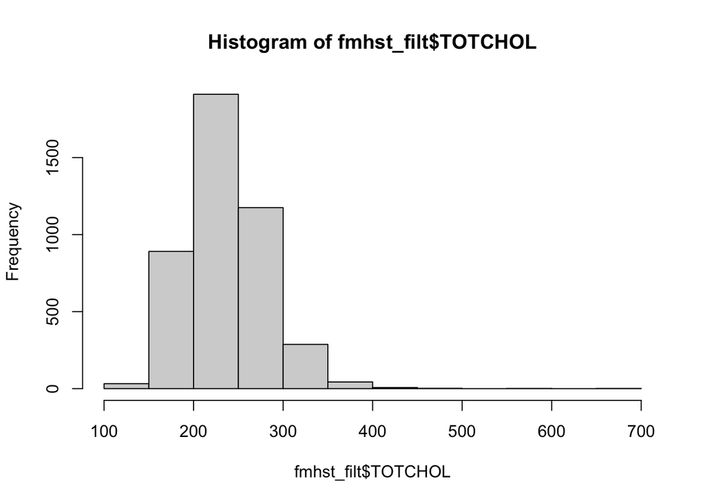

```r
hist(fmhst_filt$TOTCHOL)
```

```r
# crude incidence
fmhst_filt %>%
  group_by(SEX) %>%
  summarise(
    events = sum(STROKE_10y == "Yes"),
    total = n(),
    risk = round( (events / total)*100,1 ))
```

```
## # A tibble: 2 × 4
##   SEX   events total  risk
##   <fct>  <int> <int> <dbl>
## 1 Men       49  1930   2.5
## 2 Women     62  2472   2.5
```

### Correlations & Associations

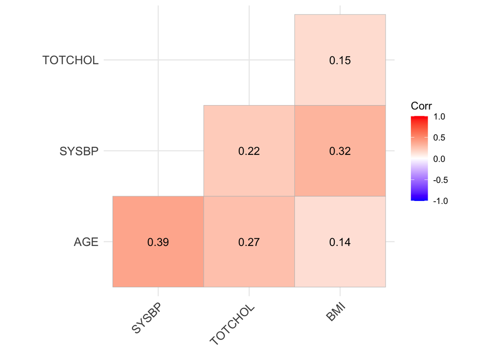

```r
corr_vars <- c("AGE", "SYSBP", "TOTCHOL", "BMI")

cor_matrix <- cor(
  fmhst_filt[, corr_vars],
  use = "pairwise.complete.obs",
  method = "spearman")

ggcorrplot(cor_matrix,
           type = "lower",
           lab = T)
```

```r
tab <- table(fmhst_filt$DIABETES, fmhst_filt$PREVCHD)
cramerV(tab)
```

```
## Cramer V
##  0.04129
```

Test association of BP and BP medication use btw Women & Men

```r
fmhst_complete <- fmhst_filt %>% filter(!is.na(SYSBP), !is.na(BPMEDS))
t.test(log(SYSBP) ~ BPMEDS, data = subset(fmhst_complete, SEX=="Women"))
```

```
##
##  Welch Two Sample t-test
##
## data:  log(SYSBP) by BPMEDS
## t = -13.593, df = 103.56, p-value < 2.2e-16
## alternative hypothesis: true difference in means between group No and group Yes is not equal to 0
## 95 percent confidence interval:
##  -0.2603942 -0.1940896
## sample estimates:
##  mean in group No mean in group Yes
##          4.870545          5.097787
```

```r
t.test(log(SYSBP) ~ BPMEDS, data = subset(fmhst_complete, SEX=="Men"))
```

```
##
##  Welch Two Sample t-test
##
## data:  log(SYSBP) by BPMEDS
## t = -8.5323, df = 40.276, p-value = 1.44e-10
## alternative hypothesis: true difference in means between group No and group Yes is not equal to 0
## 95 percent confidence interval:
##  -0.2642412 -0.1630493
## sample estimates:
##  mean in group No mean in group Yes
##          4.864984          5.078629
```

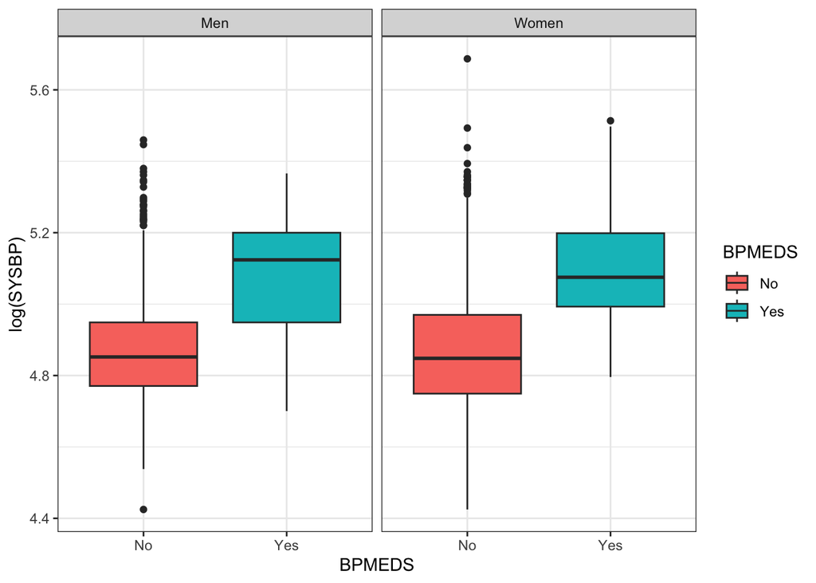

```r
ggplot(fmhst_complete, aes(x = BPMEDS, y = log(SYSBP), fill = BPMEDS)) +
  facet_wrap(~SEX) +
  geom_boxplot() + theme_bw()
```

### Kaplan-Meier Curve

```r
make_stroke_plot <- function(data, sex, vars, title = NULL) {
  plot_data <- data %>%
    filter(SEX == sex) %>%
    mutate(
      SBP_cat     = if_else(SYSBP >= 160, "BP≥160", "BP<160"),
      AGE_cat     = if_else(AGE >= 60, "Age≥60", "Age<60"),
      TOTCHOL_cat = if_else(TOTCHOL >= 240, "Chol≥240", "Chol<240"),
      BMI_cat     = if_else(BMI >= 30, "BMI≥30", "BMI<30")) %>%
    select(TIMESTRKorCENS_10y, STROKE_10y, all_of(names(vars))) %>%
    pivot_longer(
      cols = -c(TIMESTRKorCENS_10y, STROKE_10y),
      names_to = "variable",
      values_to = "group") %>%
    mutate(
      variable = factor(variable,
        levels = names(vars),
        labels = unname(vars)))

  fit <- survfit(
    Surv(TIMESTRKorCENS_10y, STROKE_10y == "Yes") ~ group + variable,
    data = plot_data)

  p <- ggsurvplot_facet(
    fit,
    data = plot_data,
    facet.by = "variable",
    conf.int = F,
    # pval = T,
    # pval.method = T,
    ylim = c(0.97, 1),
    xlab = "Time (Days)",
    ylab = "Stroke-free probability",
    title = title,
    ggtheme = theme_bw() )

  p <- p + theme(legend.position = "bottom")
  p
}
```

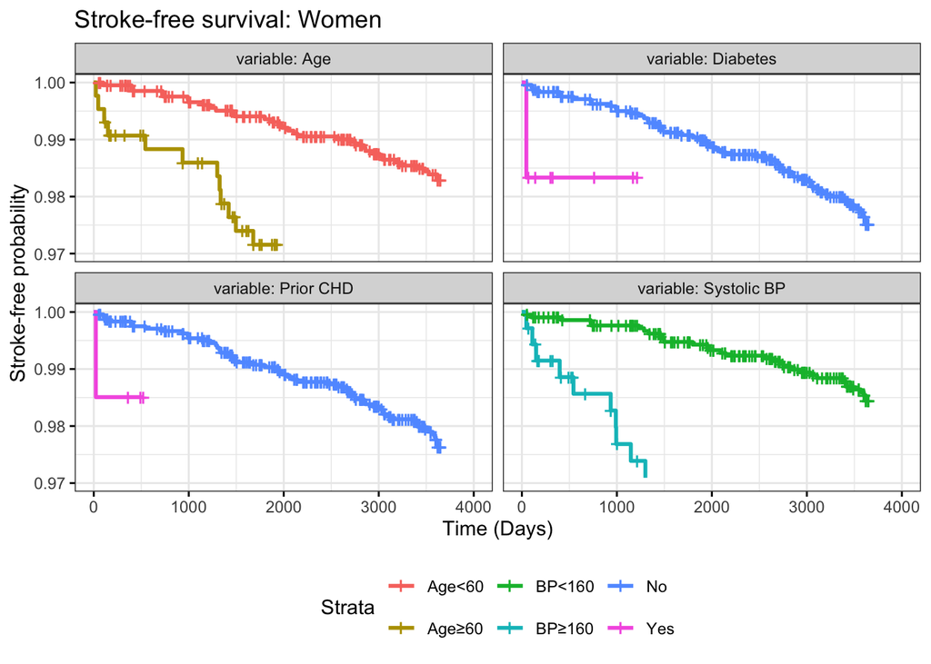

```r
vars1 <- c(
  AGE_cat  = "Age",
  SBP_cat  = "Systolic BP",
  DIABETES = "Diabetes",
  PREVCHD  = "Prior CHD")

vars2 <- c(
  TOTCHOL_cat = "Total Chol",
  BMI_cat     = "BMI",
  BPMEDS      = "BP Meds",
  CURSMOKE    = "Smoker")


p_women1 <- make_stroke_plot(
  data = fmhst_filt,
  sex = "Women",
  vars = vars1,
  title = "Stroke-free survival: Women")

p_women2 <- make_stroke_plot(
  data = fmhst_filt,
  sex = "Women",
  vars = vars2,
  title = "Stroke-free survival: Women")

p_men1 <- make_stroke_plot(
  data = fmhst_filt,
  sex = "Men",
  vars = vars1,
  title = "Stroke-free survival: Men")

p_men2 <- make_stroke_plot(
  data = fmhst_filt,
  sex = "Men",
  vars = vars2,
  title = "Stroke-free survival: Men")

p_women1
```

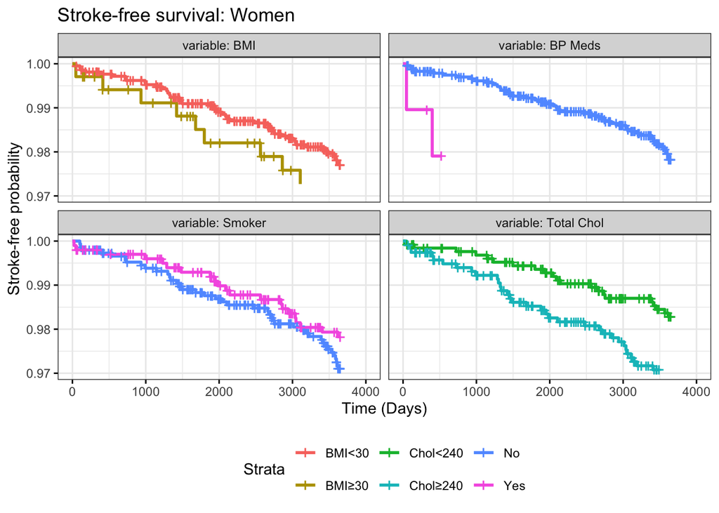

```r
p_women2
```

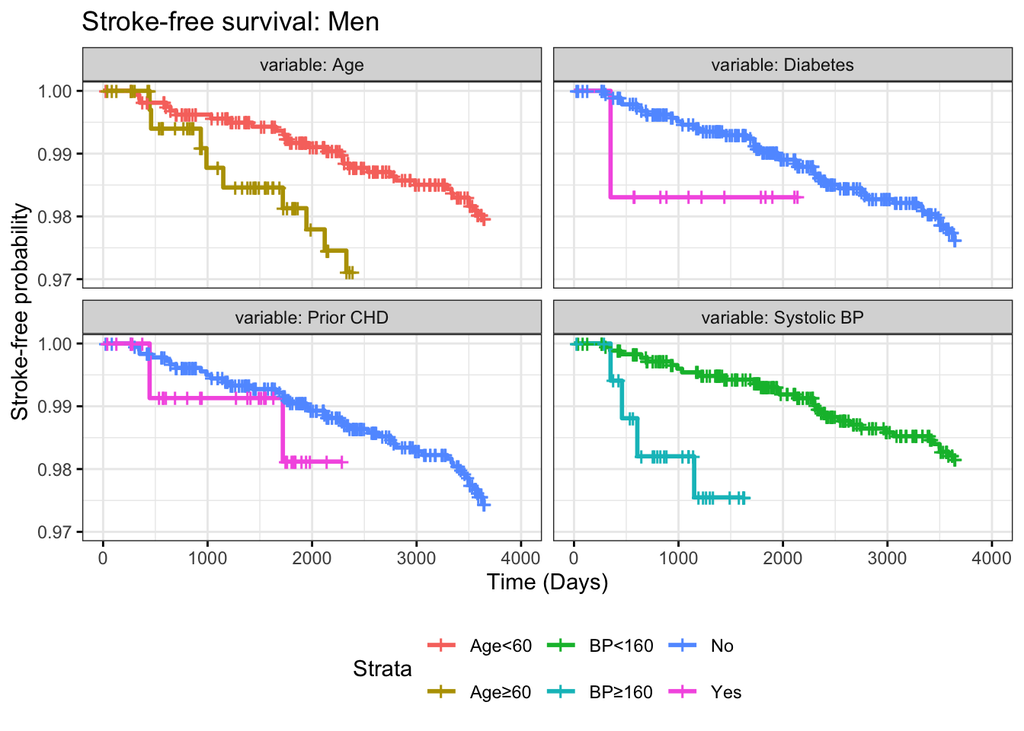

```r
p_men1
```

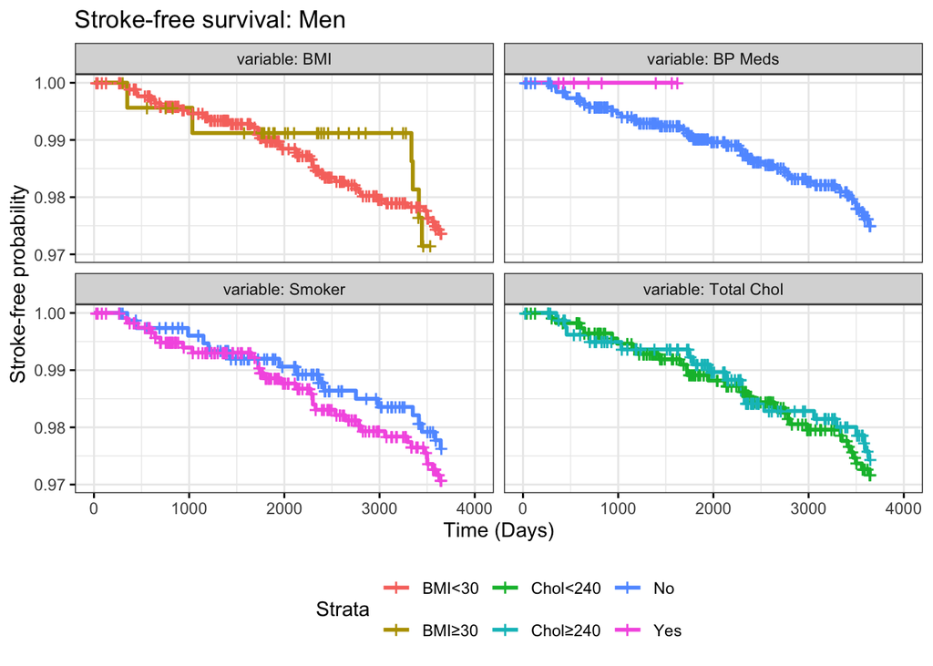

```r
p_men2
```

### Distributions of Time to Event by Sex

```r
time_vars <- c(TIMESTRKorCENS_10y = "Follow-up time (days)")

# build summary table
time_tbl <- fmhst_filt %>%
  group_by(SEX) %>%
  summarise(
    `Time to Event` = "Follow-up time (days)",
    N = sum(!is.na(TIMESTRKorCENS_10y)),
    NMiss = sum(is.na(TIMESTRKorCENS_10y)),
    Mean = mean(TIMESTRKorCENS_10y, na.rm = TRUE),
    Std = sd(TIMESTRKorCENS_10y, na.rm = TRUE),
    Min = min(TIMESTRKorCENS_10y, na.rm = TRUE),
    P25 = quantile(TIMESTRKorCENS_10y, 0.25, na.rm = TRUE),
    Median = median(TIMESTRKorCENS_10y, na.rm = TRUE),
    P75 = quantile(TIMESTRKorCENS_10y, 0.75, na.rm = TRUE),
    Max = max(TIMESTRKorCENS_10y, na.rm = TRUE),
    .groups = "drop") %>%
  # indent labels within sex groups
  mutate(SEX = if_else(duplicated(SEX), "", as.character(SEX))) %>%
  gt(groupname_col = "SEX") %>%
  tab_header(title = "Distributions of Time to Event by Sex") %>%
  cols_label(
    `Time to Event` = "Time to Event",
    N = "N",
    NMiss = "NMiss",
    Mean = "Mean",
    Std = "Std",
    Min = "Min",
    P25 = "P25",
    Median = "Median",
    P75 = "P75",
    Max = "Max") %>%
  fmt_number(
    columns = c(Mean, Std, Min, P25, Median, P75, Max),
    decimals = 0) %>%
  cols_align(
    align = "left",
    columns = c(`Time to Event`)) %>%
  cols_align(
    align = "center",
    columns = c(N, NMiss, Mean, Std, Min, P25, Median, P75, Max)) %>%
  tab_options(
    table.font.size = px(16),
    heading.align = "left",
    data_row.padding = px(6),
    row_group.font.weight = "normal",
    column_labels.font.weight = "normal",
    table.border.top.width = px(1),
    table.border.bottom.width = px(1))

time_tbl
```

Distributions of Time to Event by Sex

| Time to Event | N | NMiss | Mean | Std | Min | P25 | Median | P75 | Max |
| --- | --- | --- | --- | --- | --- | --- | --- | --- | --- |
| Men |  |  |  |  |  |  |  |  |  |
| Follow-up time (days) | 1930 | 0 | 3,432 | 665 | 26 | 3,652 | 3,652 | 3,652 | 3,652 |
| Women |  |  |  |  |  |  |  |  |  |
| Follow-up time (days) | 2472 | 0 | 3,505 | 563 | 22 | 3,652 | 3,652 | 3,652 | 3,652 |

## Primary Analysis

**Risk Factors**

### Variable Selection

Proportional assumption - low p-values indicates variable has time dependency “the proportionality assumption does not check linearity - the Cox PH model is semi-parametric and thus makes no assumption as to the form of the hazard. The proportionality assumption is that the hazard rate of an individual is relatively constant in time” * semi-parametric = don’t have to choose prob dist’n for surv time

```r
# stratify datae in women and men
vars <- c("AGE", "SYSBP_10", "DIABETES", "TOTCHOL_10",
          "BMI", "CURSMOKE", "BPMEDS", "PREVCHD",
          "TIMESTRKorCENS_10y", "STROKE_bin")

men_dat <- subset(fmhst_filt, SEX == "Men", select = vars)
men_dat <- na.omit(men_dat)

women_dat <- subset(fmhst_filt, SEX == "Women", select = vars)
women_dat <- na.omit(women_dat)
```

#### Full model (Men)

```r
cox.men.model <- coxph(
  Surv(TIMESTRKorCENS_10y, STROKE_bin) ~ AGE + SYSBP_10*BPMEDS + DIABETES +
    # variables to be determined
    TOTCHOL_10 + BMI + CURSMOKE + PREVCHD,
  data = men_dat)

summary(cox.men.model)
```

```
## Call:
## coxph(formula = Surv(TIMESTRKorCENS_10y, STROKE_bin) ~ AGE +
##     SYSBP_10 * BPMEDS + DIABETES + TOTCHOL_10 + BMI + CURSMOKE +
##     PREVCHD, data = men_dat)
##
##   n= 1897, number of events= 48
##
##                          coef  exp(coef)   se(coef)      z Pr(>|z|)
## AGE                 6.503e-02  1.067e+00  1.983e-02  3.279 0.001040 **
## SYSBP_10            3.475e-01  1.416e+00  6.127e-02  5.672 1.41e-08 ***
## BPMEDSYes           8.096e+00  3.281e+03  3.304e+00  2.450 0.014284 *
## DIABETESYes         1.626e+00  5.082e+00  4.291e-01  3.788 0.000152 ***
## TOTCHOL_10          1.960e-02  1.020e+00  3.139e-02  0.624 0.532337
## BMI                -4.282e-03  9.957e-01  4.410e-02 -0.097 0.922650
## CURSMOKEYes         6.616e-01  1.938e+00  3.233e-01  2.046 0.040710 *
## PREVCHDYes          3.925e-03  1.004e+00  5.417e-01  0.007 0.994218
## SYSBP_10:BPMEDSYes -4.393e-01  6.445e-01  2.073e-01 -2.120 0.034046 *
## ---
## Signif. codes:  0 '***' 0.001 '**' 0.01 '*' 0.05 '.' 0.1 ' ' 1
##
##                    exp(coef) exp(-coef) lower .95 upper .95
## AGE                   1.0672  0.9370402    1.0265 1.109e+00
## SYSBP_10              1.4156  0.7064246    1.2554 1.596e+00
## BPMEDSYes          3280.7394  0.0003048    5.0501 2.131e+06
## DIABETESYes           5.0816  0.1967880    2.1914 1.178e+01
## TOTCHOL_10            1.0198  0.9805898    0.9589 1.085e+00
## BMI                   0.9957  1.0042913    0.9133 1.086e+00
## CURSMOKEYes           1.9379  0.5160283    1.0284 3.652e+00
## PREVCHDYes            1.0039  0.9960825    0.3472 2.902e+00
## SYSBP_10:BPMEDSYes    0.6445  1.5516639    0.4293 9.675e-01
##
## Concordance= 0.808  (se = 0.031 )
## Likelihood ratio test= 75.09  on 9 df,   p=2e-12
## Wald test            = 82.25  on 9 df,   p=6e-14
## Score (logrank) test = 105.9  on 9 df,   p=<2e-16
```

StepReg:

```r
form <- Surv(TIMESTRKorCENS_10y, STROKE_bin) ~ AGE + SYSBP_10*BPMEDS + DIABETES +
    TOTCHOL_10 + BMI + CURSMOKE + PREVCHD

step.fit.men <- stepwise(formula = form,
                data = men_dat,
                type = "cox",
                include = c("AGE", "DIABETES", "SYSBP_10"),
                strategy = "backward",
                metric = c("AICc", "SBC", "HQ"))

summary(step.fit.men$backward$AICc)
```

```
## Call:
## coxph(formula = Surv(TIMESTRKorCENS_10y, STROKE_bin) ~ AGE +
##     DIABETES + SYSBP_10 + CURSMOKE, data = data, weights = NULL,
##     method = "efron")
##
##   n= 1897, number of events= 48
##
##                coef exp(coef) se(coef)     z Pr(>|z|)
## AGE         0.06420   1.06630  0.01906 3.368 0.000757 ***
## DIABETESYes 1.56998   4.80654  0.42263 3.715 0.000203 ***
## SYSBP_10    0.33458   1.39735  0.05736 5.833 5.45e-09 ***
## CURSMOKEYes 0.65458   1.92433  0.31570 2.073 0.038133 *
## ---
## Signif. codes:  0 '***' 0.001 '**' 0.01 '*' 0.05 '.' 0.1 ' ' 1
##
##             exp(coef) exp(-coef) lower .95 upper .95
## AGE             1.066     0.9378     1.027     1.107
## DIABETESYes     4.807     0.2080     2.099    11.005
## SYSBP_10        1.397     0.7156     1.249     1.564
## CURSMOKEYes     1.924     0.5197     1.036     3.573
##
## Concordance= 0.797  (se = 0.031 )
## Likelihood ratio test= 69.32  on 4 df,   p=3e-14
## Wald test            = 78.97  on 4 df,   p=3e-16
## Score (logrank) test = 97.01  on 4 df,   p=<2e-16
```

```r
summary(step.fit.men$backward$SBC)
```

```
## Call:
## coxph(formula = Surv(TIMESTRKorCENS_10y, STROKE_bin) ~ AGE +
##     DIABETES + SYSBP_10 + CURSMOKE, data = data, weights = NULL,
##     method = "efron")
##
##   n= 1897, number of events= 48
##
##                coef exp(coef) se(coef)     z Pr(>|z|)
## AGE         0.06420   1.06630  0.01906 3.368 0.000757 ***
## DIABETESYes 1.56998   4.80654  0.42263 3.715 0.000203 ***
## SYSBP_10    0.33458   1.39735  0.05736 5.833 5.45e-09 ***
## CURSMOKEYes 0.65458   1.92433  0.31570 2.073 0.038133 *
## ---
## Signif. codes:  0 '***' 0.001 '**' 0.01 '*' 0.05 '.' 0.1 ' ' 1
##
##             exp(coef) exp(-coef) lower .95 upper .95
## AGE             1.066     0.9378     1.027     1.107
## DIABETESYes     4.807     0.2080     2.099    11.005
## SYSBP_10        1.397     0.7156     1.249     1.564
## CURSMOKEYes     1.924     0.5197     1.036     3.573
##
## Concordance= 0.797  (se = 0.031 )
## Likelihood ratio test= 69.32  on 4 df,   p=3e-14
## Wald test            = 78.97  on 4 df,   p=3e-16
## Score (logrank) test = 97.01  on 4 df,   p=<2e-16
```

```r
summary(step.fit.men$backward$HQ)
```

```
## Call:
## coxph(formula = Surv(TIMESTRKorCENS_10y, STROKE_bin) ~ AGE +
##     DIABETES + SYSBP_10 + CURSMOKE, data = data, weights = NULL,
##     method = "efron")
##
##   n= 1897, number of events= 48
##
##                coef exp(coef) se(coef)     z Pr(>|z|)
## AGE         0.06420   1.06630  0.01906 3.368 0.000757 ***
## DIABETESYes 1.56998   4.80654  0.42263 3.715 0.000203 ***
## SYSBP_10    0.33458   1.39735  0.05736 5.833 5.45e-09 ***
## CURSMOKEYes 0.65458   1.92433  0.31570 2.073 0.038133 *
## ---
## Signif. codes:  0 '***' 0.001 '**' 0.01 '*' 0.05 '.' 0.1 ' ' 1
##
##             exp(coef) exp(-coef) lower .95 upper .95
## AGE             1.066     0.9378     1.027     1.107
## DIABETESYes     4.807     0.2080     2.099    11.005
## SYSBP_10        1.397     0.7156     1.249     1.564
## CURSMOKEYes     1.924     0.5197     1.036     3.573
##
## Concordance= 0.797  (se = 0.031 )
## Likelihood ratio test= 69.32  on 4 df,   p=3e-14
## Wald test            = 78.97  on 4 df,   p=3e-16
## Score (logrank) test = 97.01  on 4 df,   p=<2e-16
```

```r
performance(step.fit.men)
```

```
##                                                                         model
## 1 Surv(TIMESTRKorCENS_10y, STROKE_bin) ~ AGE + DIABETES + SYSBP_10 + CURSMOKE
##                            strategy:metric c-index_train c-index_test auc_sh
## 1 backward:AICc; backward:SBC; backward:HQ        0.7971           NA     NA
```

```r
summary(step.fit.men$backward$AICc)
```

```
## Call:
## coxph(formula = Surv(TIMESTRKorCENS_10y, STROKE_bin) ~ AGE +
##     DIABETES + SYSBP_10 + CURSMOKE, data = data, weights = NULL,
##     method = "efron")
##
##   n= 1897, number of events= 48
##
##                coef exp(coef) se(coef)     z Pr(>|z|)
## AGE         0.06420   1.06630  0.01906 3.368 0.000757 ***
## DIABETESYes 1.56998   4.80654  0.42263 3.715 0.000203 ***
## SYSBP_10    0.33458   1.39735  0.05736 5.833 5.45e-09 ***
## CURSMOKEYes 0.65458   1.92433  0.31570 2.073 0.038133 *
## ---
## Signif. codes:  0 '***' 0.001 '**' 0.01 '*' 0.05 '.' 0.1 ' ' 1
##
##             exp(coef) exp(-coef) lower .95 upper .95
## AGE             1.066     0.9378     1.027     1.107
## DIABETESYes     4.807     0.2080     2.099    11.005
## SYSBP_10        1.397     0.7156     1.249     1.564
## CURSMOKEYes     1.924     0.5197     1.036     3.573
##
## Concordance= 0.797  (se = 0.031 )
## Likelihood ratio test= 69.32  on 4 df,   p=3e-14
## Wald test            = 78.97  on 4 df,   p=3e-16
## Score (logrank) test = 97.01  on 4 df,   p=<2e-16
```

```r
summary(step.fit.men$backward$SL)
```

```
## Length  Class   Mode
##      0   NULL   NULL
```

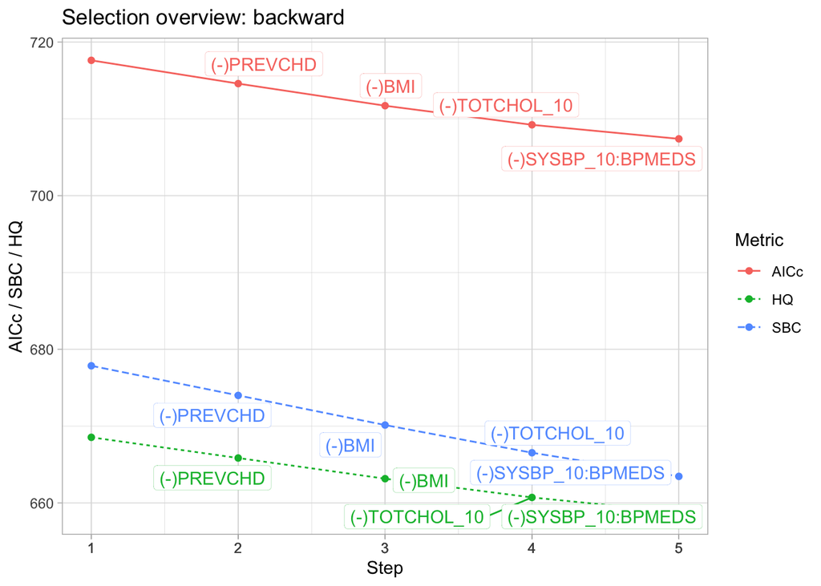

```r
plot(step.fit.men, strategy = "backward", process = "overview")
```

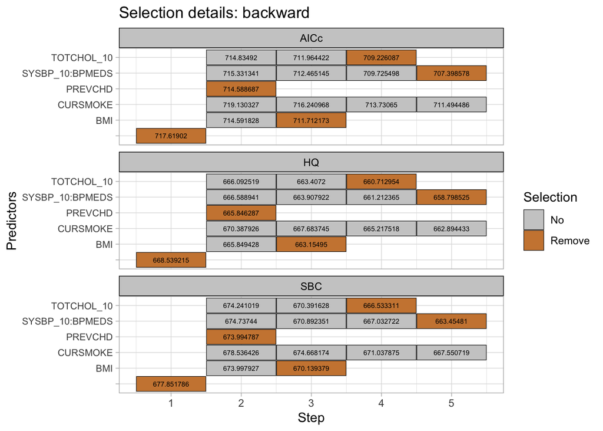

```r
plot(step.fit.men, strategy = "backward", process = "detail")
```

Plot details of stepwise

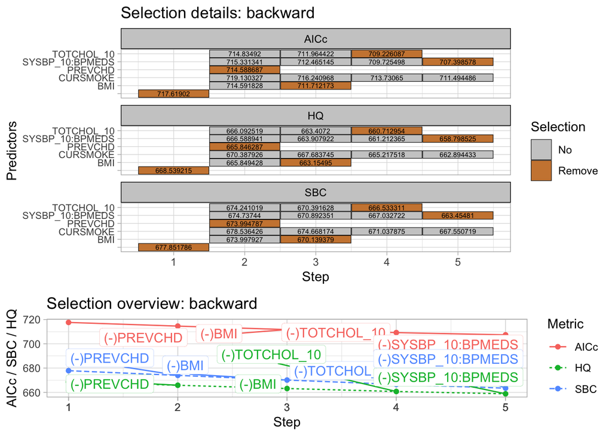

```r
plot_list <- setNames(
  lapply(c("backward"),function(i){
    setNames(
      lapply(c("detail","overview"),function(j){
        plot(step.fit.men, strategy=i, process=j)
    }),
    c("detail","overview"))
  }),
  c("backward"))

cowplot::plot_grid(plotlist = plot_list$backward, ncol = 1,
                   rel_heights = c(2, 1))
```

```r
step.men <- step(cox.men.model,
     direction = "backward",
     scope = list(lower = ~ AGE + SYSBP_10 + DIABETES))
```

```
## Start:  AIC=660.2
## Surv(TIMESTRKorCENS_10y, STROKE_bin) ~ AGE + SYSBP_10 * BPMEDS +
##     DIABETES + TOTCHOL_10 + BMI + CURSMOKE + PREVCHD
##
##                   Df    AIC
## - PREVCHD          1 658.20
## - BMI              1 658.21
## - TOTCHOL_10       1 658.57
## <none>               660.20
## - SYSBP_10:BPMEDS  1 662.26
## - CURSMOKE         1 662.58
##
## Step:  AIC=658.2
## Surv(TIMESTRKorCENS_10y, STROKE_bin) ~ AGE + SYSBP_10 + BPMEDS +
##     DIABETES + TOTCHOL_10 + BMI + CURSMOKE + SYSBP_10:BPMEDS
##
##                   Df    AIC
## - BMI              1 656.21
## - TOTCHOL_10       1 656.57
## <none>               658.20
## - SYSBP_10:BPMEDS  1 660.27
## - CURSMOKE         1 660.59
##
## Step:  AIC=656.21
## Surv(TIMESTRKorCENS_10y, STROKE_bin) ~ AGE + SYSBP_10 + BPMEDS +
##     DIABETES + TOTCHOL_10 + CURSMOKE + SYSBP_10:BPMEDS
##
##                   Df    AIC
## - TOTCHOL_10       1 654.58
## <none>               656.21
## - SYSBP_10:BPMEDS  1 658.29
## - CURSMOKE         1 658.81
##
## Step:  AIC=654.58
## Surv(TIMESTRKorCENS_10y, STROKE_bin) ~ AGE + SYSBP_10 + BPMEDS +
##     DIABETES + CURSMOKE + SYSBP_10:BPMEDS
##
##                   Df    AIC
## <none>               654.58
## - SYSBP_10:BPMEDS  1 656.54
## - CURSMOKE         1 657.31
```

```r
summary(step.men)
```

```
## Call:
## coxph(formula = Surv(TIMESTRKorCENS_10y, STROKE_bin) ~ AGE +
##     SYSBP_10 + BPMEDS + DIABETES + CURSMOKE + SYSBP_10:BPMEDS,
##     data = men_dat)
##
##   n= 1897, number of events= 48
##
##                          coef  exp(coef)   se(coef)      z Pr(>|z|)
## AGE                   0.06401    1.06610    0.01903  3.364 0.000769 ***
## SYSBP_10              0.34616    1.41363    0.06035  5.736 9.69e-09 ***
## BPMEDSYes             7.95285 2843.66499    3.26015  2.439 0.014711 *
## DIABETESYes           1.61708    5.03836    0.42606  3.795 0.000147 ***
## CURSMOKEYes           0.67535    1.96473    0.31785  2.125 0.033606 *
## SYSBP_10:BPMEDSYes   -0.43045    0.65022    0.20462 -2.104 0.035414 *
## ---
## Signif. codes:  0 '***' 0.001 '**' 0.01 '*' 0.05 '.' 0.1 ' ' 1
##
##                    exp(coef) exp(-coef) lower .95 upper .95
## AGE                   1.0661  0.9379998    1.0271 1.107e+00
## SYSBP_10              1.4136  0.7073999    1.2559 1.591e+00
## BPMEDSYes          2843.6650  0.0003517    4.7735 1.694e+06
## DIABETESYes           5.0384  0.1984773    2.1859 1.161e+01
## CURSMOKEYes           1.9647  0.5089769    1.0538 3.663e+00
## SYSBP_10:BPMEDSYes    0.6502  1.5379439    0.4354 9.710e-01
##
## Concordance= 0.806  (se = 0.031 )
## Likelihood ratio test= 74.72  on 6 df,   p=4e-14
## Wald test            = 82.98  on 6 df,   p=9e-16
## Score (logrank) test = 105.4  on 6 df,   p=<2e-16
```

#### Full model (Women)

```r
cox.women.model <- coxph(
  Surv(TIMESTRKorCENS_10y, STROKE_bin) ~ AGE + SYSBP_10*BPMEDS + DIABETES +
    # variables to be determined
    TOTCHOL_10 + BMI + CURSMOKE + PREVCHD,
  data = women_dat)

summary(cox.women.model)
```

```
## Call:
## coxph(formula = Surv(TIMESTRKorCENS_10y, STROKE_bin) ~ AGE +
##     SYSBP_10 * BPMEDS + DIABETES + TOTCHOL_10 + BMI + CURSMOKE +
##     PREVCHD, data = women_dat)
##
##   n= 2378, number of events= 57
##
##                        coef exp(coef) se(coef)      z Pr(>|z|)
## AGE                 0.07429   1.07712  0.02051  3.622 0.000293 ***
## SYSBP_10            0.25376   1.28886  0.05079  4.996 5.84e-07 ***
## BPMEDSYes           0.71308   2.04027  2.18841  0.326 0.744542
## DIABETESYes         0.61903   1.85713  0.52438  1.181 0.237799
## TOTCHOL_10         -0.01584   0.98429  0.03020 -0.524 0.599975
## BMI                -0.01026   0.98979  0.02668 -0.384 0.700617
## CURSMOKEYes         0.35588   1.42743  0.28870  1.233 0.217688
## PREVCHDYes          0.47606   1.60971  0.44642  1.066 0.286253
## SYSBP_10:BPMEDSYes -0.01574   0.98438  0.11838 -0.133 0.894212
## ---
## Signif. codes:  0 '***' 0.001 '**' 0.01 '*' 0.05 '.' 0.1 ' ' 1
##
##                    exp(coef) exp(-coef) lower .95 upper .95
## AGE                   1.0771     0.9284   1.03467     1.121
## SYSBP_10              1.2889     0.7759   1.16674     1.424
## BPMEDSYes             2.0403     0.4901   0.02798   148.752
## DIABETESYes           1.8571     0.5385   0.66449     5.190
## TOTCHOL_10            0.9843     1.0160   0.92773     1.044
## BMI                   0.9898     1.0103   0.93936     1.043
## CURSMOKEYes           1.4274     0.7006   0.81062     2.514
## PREVCHDYes            1.6097     0.6212   0.67105     3.861
## SYSBP_10:BPMEDSYes    0.9844     1.0159   0.78055     1.241
##
## Concordance= 0.802  (se = 0.03 )
## Likelihood ratio test= 83.2  on 9 df,   p=4e-14
## Wald test            = 89.66  on 9 df,   p=2e-15
## Score (logrank) test = 128.4  on 9 df,   p=<2e-16
```

```r
step.fit.women <- stepwise(formula = form,
                data = women_dat,
                type = "cox",
                include = c("AGE", "DIABETES", "SYSBP_10"),
                strategy = "backward",
                metric = c("AICc", "SBC", "HQ"))

summary(step.fit.women$backward$AICc)
```

```
## Call:
## coxph(formula = Surv(TIMESTRKorCENS_10y, STROKE_bin) ~ AGE +
##     DIABETES + SYSBP_10 + CURSMOKE, data = data, weights = NULL,
##     method = "efron")
##
##   n= 2378, number of events= 57
##
##                coef exp(coef) se(coef)     z Pr(>|z|)
## AGE         0.07545   1.07837  0.01996 3.781 0.000156 ***
## DIABETESYes 0.59400   1.81122  0.52125 1.140 0.254465
## SYSBP_10    0.26039   1.29743  0.04141 6.288 3.21e-10 ***
## CURSMOKEYes 0.36149   1.43546  0.28623 1.263 0.206614
## ---
## Signif. codes:  0 '***' 0.001 '**' 0.01 '*' 0.05 '.' 0.1 ' ' 1
##
##             exp(coef) exp(-coef) lower .95 upper .95
## AGE             1.078     0.9273    1.0370     1.121
## DIABETESYes     1.811     0.5521    0.6521     5.031
## SYSBP_10        1.297     0.7708    1.1963     1.407
## CURSMOKEYes     1.435     0.6966    0.8191     2.516
##
## Concordance= 0.799  (se = 0.029 )
## Likelihood ratio test= 80.39  on 4 df,   p=<2e-16
## Wald test            = 85.73  on 4 df,   p=<2e-16
## Score (logrank) test = 100.5  on 4 df,   p=<2e-16
```

```r
summary(step.fit.women$backward$SBC)
```

```
## Call:
## coxph(formula = Surv(TIMESTRKorCENS_10y, STROKE_bin) ~ AGE +
##     DIABETES + SYSBP_10 + CURSMOKE, data = data, weights = NULL,
##     method = "efron")
##
##   n= 2378, number of events= 57
##
##                coef exp(coef) se(coef)     z Pr(>|z|)
## AGE         0.07545   1.07837  0.01996 3.781 0.000156 ***
## DIABETESYes 0.59400   1.81122  0.52125 1.140 0.254465
## SYSBP_10    0.26039   1.29743  0.04141 6.288 3.21e-10 ***
## CURSMOKEYes 0.36149   1.43546  0.28623 1.263 0.206614
## ---
## Signif. codes:  0 '***' 0.001 '**' 0.01 '*' 0.05 '.' 0.1 ' ' 1
##
##             exp(coef) exp(-coef) lower .95 upper .95
## AGE             1.078     0.9273    1.0370     1.121
## DIABETESYes     1.811     0.5521    0.6521     5.031
## SYSBP_10        1.297     0.7708    1.1963     1.407
## CURSMOKEYes     1.435     0.6966    0.8191     2.516
##
## Concordance= 0.799  (se = 0.029 )
## Likelihood ratio test= 80.39  on 4 df,   p=<2e-16
## Wald test            = 85.73  on 4 df,   p=<2e-16
## Score (logrank) test = 100.5  on 4 df,   p=<2e-16
```

```r
summary(step.fit.women$backward$HQ)
```

```
## Call:
## coxph(formula = Surv(TIMESTRKorCENS_10y, STROKE_bin) ~ AGE +
##     DIABETES + SYSBP_10 + CURSMOKE, data = data, weights = NULL,
##     method = "efron")
##
##   n= 2378, number of events= 57
##
##                coef exp(coef) se(coef)     z Pr(>|z|)
## AGE         0.07545   1.07837  0.01996 3.781 0.000156 ***
## DIABETESYes 0.59400   1.81122  0.52125 1.140 0.254465
## SYSBP_10    0.26039   1.29743  0.04141 6.288 3.21e-10 ***
## CURSMOKEYes 0.36149   1.43546  0.28623 1.263 0.206614
## ---
## Signif. codes:  0 '***' 0.001 '**' 0.01 '*' 0.05 '.' 0.1 ' ' 1
##
##             exp(coef) exp(-coef) lower .95 upper .95
## AGE             1.078     0.9273    1.0370     1.121
## DIABETESYes     1.811     0.5521    0.6521     5.031
## SYSBP_10        1.297     0.7708    1.1963     1.407
## CURSMOKEYes     1.435     0.6966    0.8191     2.516
##
## Concordance= 0.799  (se = 0.029 )
## Likelihood ratio test= 80.39  on 4 df,   p=<2e-16
## Wald test            = 85.73  on 4 df,   p=<2e-16
## Score (logrank) test = 100.5  on 4 df,   p=<2e-16
```

```r
performance(step.fit.women)
```

```
##                                                                         model
## 1 Surv(TIMESTRKorCENS_10y, STROKE_bin) ~ AGE + DIABETES + SYSBP_10 + CURSMOKE
##                            strategy:metric c-index_train c-index_test auc_sh
## 1 backward:AICc; backward:SBC; backward:HQ        0.7991           NA     NA
```

[figure not shown]

```r
plot_list2 <- setNames(
  lapply(c("backward"), function(i){
    setNames(
      lapply(c("detail","overview"), function(j){
        plot(step.fit.women, strategy=i, process=j)
    }),
    c("detail","overview"))
  }),
  c("backward"))

cowplot::plot_grid(plotlist = plot_list2$backward, ncol = 2,
                   rel_heights = c(2, 1))
```

```r
step.women <- step(cox.women.model,
     direction = "backward",
     scope = list(lower = ~ AGE + SYSBP_10 + DIABETES))
```

```
## Start:  AIC=815.93
## Surv(TIMESTRKorCENS_10y, STROKE_bin) ~ AGE + SYSBP_10 * BPMEDS +
##     DIABETES + TOTCHOL_10 + BMI + CURSMOKE + PREVCHD
##
##                   Df    AIC
## - SYSBP_10:BPMEDS  1 813.95
## - BMI              1 814.08
## - TOTCHOL_10       1 814.21
## - PREVCHD          1 814.95
## - CURSMOKE         1 815.40
## <none>               815.93
##
## Step:  AIC=813.95
## Surv(TIMESTRKorCENS_10y, STROKE_bin) ~ AGE + SYSBP_10 + BPMEDS +
##     DIABETES + TOTCHOL_10 + BMI + CURSMOKE + PREVCHD
##
##              Df    AIC
## - BMI         1 812.08
## - TOTCHOL_10  1 812.23
## - PREVCHD     1 812.97
## - BPMEDS      1 813.07
## - CURSMOKE    1 813.43
## <none>          813.95
##
## Step:  AIC=812.08
## Surv(TIMESTRKorCENS_10y, STROKE_bin) ~ AGE + SYSBP_10 + BPMEDS +
##     DIABETES + TOTCHOL_10 + CURSMOKE + PREVCHD
##
##              Df    AIC
## - TOTCHOL_10  1 810.35
## - PREVCHD     1 811.13
## - BPMEDS      1 811.24
## - CURSMOKE    1 811.68
## <none>          812.08
##
## Step:  AIC=810.35
## Surv(TIMESTRKorCENS_10y, STROKE_bin) ~ AGE + SYSBP_10 + BPMEDS +
##     DIABETES + CURSMOKE + PREVCHD
##
##            Df    AIC
```

[output cut: 9 more lines]

```
##            Df    AIC
## - PREVCHD   1 808.74
## - CURSMOKE  1 809.07
## <none>        809.43
##
## Step:  AIC=808.74
## Surv(TIMESTRKorCENS_10y, STROKE_bin) ~ AGE + SYSBP_10 + DIABETES +
##     CURSMOKE
##
##            Df    AIC
## - CURSMOKE  1 808.28
## <none>        808.74
##
## Step:  AIC=808.28
## Surv(TIMESTRKorCENS_10y, STROKE_bin) ~ AGE + SYSBP_10 + DIABETES
```

```r
summary(step.women)
```

```
## Call:
## coxph(formula = Surv(TIMESTRKorCENS_10y, STROKE_bin) ~ AGE +
##     SYSBP_10 + DIABETES, data = women_dat)
##
##   n= 2378, number of events= 57
##
##                coef exp(coef) se(coef)     z Pr(>|z|)
## AGE         0.07092   1.07350  0.01961 3.617 0.000298 ***
## SYSBP_10    0.25706   1.29313  0.04110 6.254    4e-10 ***
## DIABETESYes 0.56911   1.76669  0.52093 1.092 0.274623
## ---
## Signif. codes:  0 '***' 0.001 '**' 0.01 '*' 0.05 '.' 0.1 ' ' 1
##
##             exp(coef) exp(-coef) lower .95 upper .95
## AGE             1.073     0.9315    1.0330     1.116
## SYSBP_10        1.293     0.7733    1.1930     1.402
## DIABETESYes     1.767     0.5660    0.6364     4.904
##
## Concordance= 0.796  (se = 0.03 )
## Likelihood ratio test= 78.85  on 3 df,   p=<2e-16
## Wald test            = 84.64  on 3 df,   p=<2e-16
## Score (logrank) test = 98.71  on 3 df,   p=<2e-16
```

```r
#amount of women on BP meds
fmhst_filt %>%
  filter(SEX=="Women") %>%
  group_by(BPMEDS) %>%
  summarize(n = n())
```

```
## # A tibble: 3 × 2
##   BPMEDS     n
##   <fct>  <int>
## 1 No      2338
## 2 Yes       96
## 3 <NA>      38
```

### Final Models

```r
cox.women.final <- coxph(
  Surv(TIMESTRKorCENS_10y, STROKE_bin) ~ AGE + SYSBP_10*BPMEDS + DIABETES +
    CURSMOKE + PREVCHD,
  data = women_dat)

summary(cox.women.final)
```

```
## Call:
## coxph(formula = Surv(TIMESTRKorCENS_10y, STROKE_bin) ~ AGE +
##     SYSBP_10 * BPMEDS + DIABETES + CURSMOKE + PREVCHD, data = women_dat)
##
##   n= 2378, number of events= 57
##
##                        coef exp(coef) se(coef)      z Pr(>|z|)
## AGE                 0.07243   1.07511  0.02028  3.571 0.000356 ***
## SYSBP_10            0.24666   1.27974  0.04802  5.137 2.79e-07 ***
## BPMEDSYes           0.59697   1.81661  2.16522  0.276 0.782770
## DIABETESYes         0.59546   1.81387  0.52198  1.141 0.253967
## CURSMOKEYes         0.37311   1.45224  0.28681  1.301 0.193288
## PREVCHDYes          0.50273   1.65323  0.44337  1.134 0.256843
## SYSBP_10:BPMEDSYes -0.01002   0.99003  0.11692 -0.086 0.931730
## ---
## Signif. codes:  0 '***' 0.001 '**' 0.01 '*' 0.05 '.' 0.1 ' ' 1
##
##                    exp(coef) exp(-coef) lower .95 upper .95
## AGE                    1.075     0.9301   1.03321     1.119
## SYSBP_10               1.280     0.7814   1.16480     1.406
## BPMEDSYes              1.817     0.5505   0.02608   126.561
## DIABETESYes            1.814     0.5513   0.65207     5.046
## CURSMOKEYes            1.452     0.6886   0.82777     2.548
## PREVCHDYes             1.653     0.6049   0.69332     3.942
## SYSBP_10:BPMEDSYes     0.990     1.0101   0.78728     1.245
##
## Concordance= 0.803  (se = 0.029 )
## Likelihood ratio test= 82.78  on 7 df,   p=4e-15
## Wald test            = 88.13  on 7 df,   p=3e-16
## Score (logrank) test = 126  on 7 df,   p=<2e-16
```

```r
cox.men.final <- coxph(
  Surv(TIMESTRKorCENS_10y, STROKE_bin) ~ AGE + SYSBP_10*BPMEDS + DIABETES +
    CURSMOKE + PREVCHD,
  data = men_dat)

summary(cox.men.final)
```

```
## Call:
## coxph(formula = Surv(TIMESTRKorCENS_10y, STROKE_bin) ~ AGE +
##     SYSBP_10 * BPMEDS + DIABETES + CURSMOKE + PREVCHD, data = men_dat)
##
##   n= 1897, number of events= 48
##
##                          coef  exp(coef)   se(coef)      z Pr(>|z|)
## AGE                   0.06383    1.06591    0.01942  3.287 0.001013 **
## SYSBP_10              0.34635    1.41389    0.06051  5.724 1.04e-08 ***
## BPMEDSYes             7.94601 2824.27058    3.26353  2.435 0.014900 *
## DIABETESYes           1.61627    5.03426    0.42654  3.789 0.000151 ***
## CURSMOKEYes           0.67571    1.96544    0.31802  2.125 0.033605 *
## PREVCHDYes            0.02406    1.02435    0.54012  0.045 0.964473
## SYSBP_10:BPMEDSYes   -0.43018    0.65039    0.20470 -2.102 0.035596 *
## ---
## Signif. codes:  0 '***' 0.001 '**' 0.01 '*' 0.05 '.' 0.1 ' ' 1
##
##                    exp(coef) exp(-coef) lower .95 upper .95
## AGE                   1.0659  0.9381621    1.0261 1.107e+00
## SYSBP_10              1.4139  0.7072666    1.2558 1.592e+00
## BPMEDSYes          2824.2706  0.0003541    4.7096 1.694e+06
## DIABETESYes           5.0343  0.1986391    2.1820 1.161e+01
## CURSMOKEYes           1.9654  0.5087926    1.0538 3.666e+00
## PREVCHDYes            1.0243  0.9762300    0.3554 2.953e+00
## SYSBP_10:BPMEDSYes    0.6504  1.5375292    0.4354 9.714e-01
##
## Concordance= 0.806  (se = 0.031 )
## Likelihood ratio test= 74.72  on 7 df,   p=2e-13
## Wald test            = 83.01  on 7 df,   p=3e-15
## Score (logrank) test = 105.4  on 7 df,   p=<2e-16
```

Sample interpretation: Systolic BP was positively associated with stroke risk in women, with each 1 mmHg increase corresponding to a 2.5% increase in hazard (HR = 1.025; 95% CI: 1.015–1.035). This corresponds to approximately a 28% ($1.025^{10} ≈ 1.28$) increase in hazard per 10 mmHg increase.

Systolic BP was positively associated with stroke risk in men, with each 1 mmHg increase corresponding to a 3.5% increase in hazard (HR = 1.0352; 95% CI: 1.023–1.048). This corresponds to approximately a 41.3% ($1.035^{10} ≈ 1.413$) increase in hazard per 10 mmHg increase.

#### Proportionality Check

```r
ph_women <- cox.zph(cox.women.final)
ph_women
```

```
##                   chisq df     p
## AGE             0.04388  1 0.834
## SYSBP_10        0.04868  1 0.825
## BPMEDS          3.11644  1 0.078
## DIABETES        0.09397  1 0.759
## CURSMOKE        0.14328  1 0.705
## PREVCHD         0.00375  1 0.951
## SYSBP_10:BPMEDS 2.61833  1 0.106
## GLOBAL          4.13512  7 0.764
```

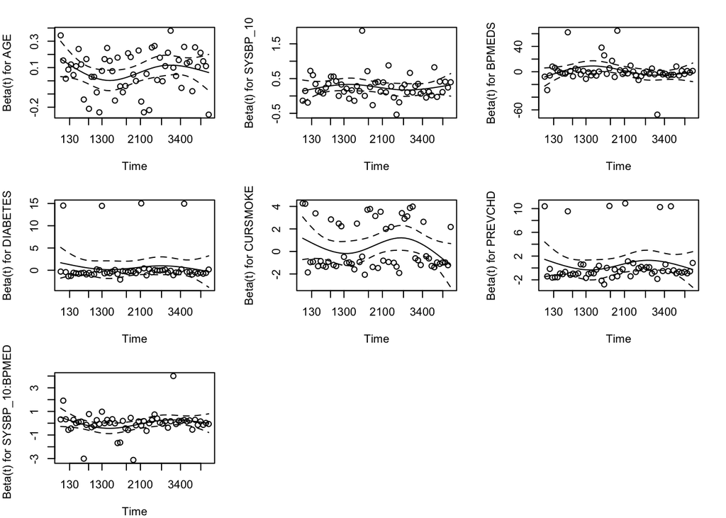

```r
par(mfrow = c(3, 3), mar = c(4, 4, 2, 2)) # c(bottom, left, top, right)
plot(ph_women)
```

```r
ph_men <- cox.zph(cox.men.final)
ph_men
```

```
##                  chisq df     p
## AGE             0.4734  1 0.491
## SYSBP_10        1.4618  1 0.227
## BPMEDS          0.0620  1 0.803
## DIABETES        2.7630  1 0.096
## CURSMOKE        0.0375  1 0.846
## PREVCHD         0.2726  1 0.602
## SYSBP_10:BPMEDS 0.1084  1 0.742
## GLOBAL          4.8993  7 0.672
```

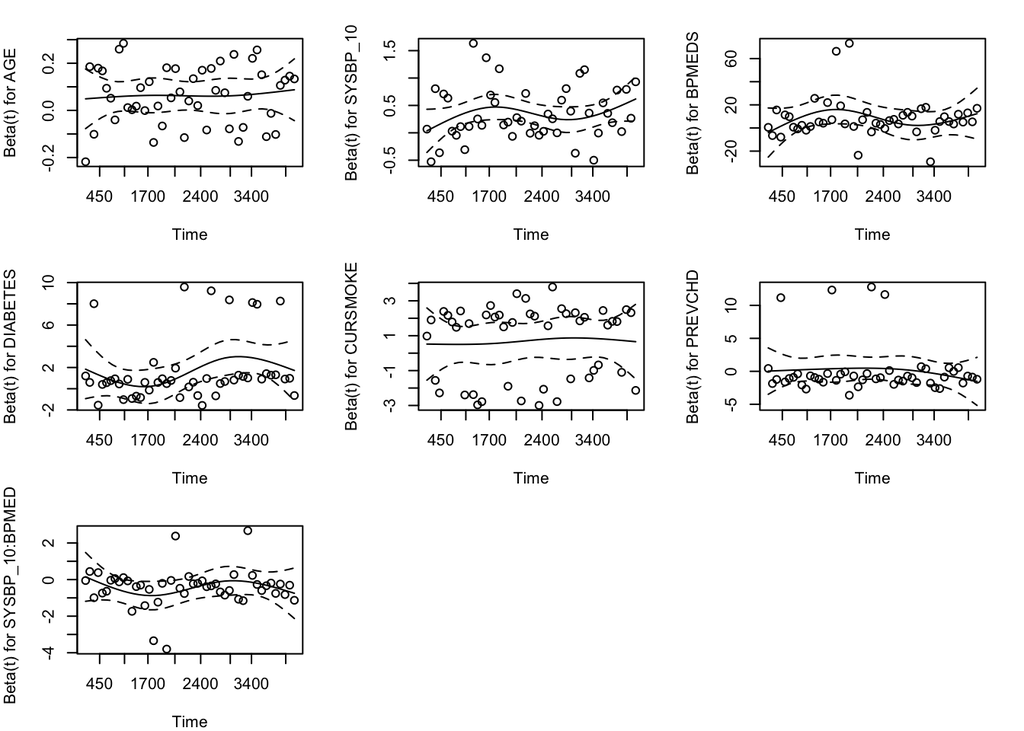

```r
par(mfrow = c(3, 3), mar = c(4, 4, 2, 2)) # c(bottom, left, top, right)
plot(ph_men)
```

#### Risk Factors Table

```r
broom::tidy(cox.men.final, exponentiate = TRUE, conf.int = TRUE) %>%
  mutate(
    pct_change = (estimate - 1) * 100,
    pct_label = paste0(
      ifelse(pct_change >= 0, "+", ""),
      round(pct_change, 1), "%"))
```

```
## # A tibble: 7 × 9
##   term        estimate std.error statistic p.value conf.low conf.high pct_change
##   <chr>          <dbl>     <dbl>     <dbl>   <dbl>    <dbl>     <dbl>      <dbl>
## 1 AGE            1.07     0.0194    3.29   1.01e-3    1.03    1.11e+0       6.59
## 2 SYSBP_10       1.41     0.0605    5.72   1.04e-8    1.26    1.59e+0      41.4
## 3 BPMEDSYes   2824.       3.26      2.43   1.49e-2    4.71    1.69e+6  282327.
## 4 DIABETESYes    5.03     0.427     3.79   1.51e-4    2.18    1.16e+1     403.
## 5 CURSMOKEYes    1.97     0.318     2.12   3.36e-2    1.05    3.67e+0      96.5
## 6 PREVCHDYes     1.02     0.540     0.0445 9.64e-1    0.355   2.95e+0       2.43
## 7 SYSBP_10:B…    0.650    0.205    -2.10   3.56e-2    0.435   9.71e-1     -35.0
## # ℹ 1 more variable: pct_label <chr>
```

```r
# helper function to generate results table
make_cox_table <- function(model, sex_label) {
  tidy(model, exponentiate = TRUE, conf.int = TRUE) %>%
    filter(term != "(Intercept)") %>%
    mutate(
      # rename terms
      term = recode(
        term,
        "AGE" = "Age (per 1 year)",
        "SYSBP_10" = "Systolic BP (per 10 mmHg)",
        "DIABETESYes" = "Diabetes (Yes vs No)",
        "TOTCHOL" = "Total cholesterol (per 1 mg/dL)",
        "BMI" = "BMI (per 1 kg/m²)",
        "CURSMOKEYes" = "Current smoker (Yes vs No)",
        "BPMEDSYes" = "BP meds (Yes vs No)",
        "PREVCHDYes" = "Cardiovascular Disease (Yes vs No)",
        "SYSBP_10:BPMEDSYes" = "SBP × BP meds interaction"),

      # percent change in hazard
      pct_change = (estimate - 1) * 100,

      # formatted columns
      hr_ci = sprintf("%.2f (%.2f, %.2f; p=%s)",estimate,conf.low,conf.high,
                      format.pval(p.value, digits = 2, eps = 0.01)),
      pct_label = sprintf(
        "%s%.1f%%",
        ifelse(pct_change >= 0, "+", ""),
        pct_change)) %>%
    select(term, hr_ci, pct_label) %>%
    rename(
      !!paste0(sex_label, "_HR_CI") := hr_ci,
      !!paste0(sex_label, "_Pct") := pct_label)
  }

tbl_women <- make_cox_table(cox.women.final, "Women")
tbl_men   <- make_cox_table(cox.men.final, "Men")

# merge
tbl_final <- full_join(tbl_women, tbl_men, by = "term") %>%
  rename(`Risk factor` = term)

tbl_final
```

```
## # A tibble: 7 × 5
##   `Risk factor`                      Women_HR_CI     Women_Pct Men_HR_CI Men_Pct
##   <chr>                              <chr>           <chr>     <chr>     <chr>
## 1 Age (per 1 year)                   1.08 (1.03, 1.… +7.5%     1.07 (1.… +6.6%
## 2 Systolic BP (per 10 mmHg)          1.28 (1.16, 1.… +28.0%    1.41 (1.… +41.4%
## 3 BP meds (Yes vs No)                1.82 (0.03, 12… +81.7%    2824.27 … +28232…
## 4 Diabetes (Yes vs No)               1.81 (0.65, 5.… +81.4%    5.03 (2.… +403.4%
## 5 Current smoker (Yes vs No)         1.45 (0.83, 2.… +45.2%    1.97 (1.… +96.5%
## 6 Cardiovascular Disease (Yes vs No) 1.65 (0.69, 3.… +65.3%    1.02 (0.… +2.4%
## 7 SBP × BP meds interaction          0.99 (0.79, 1.… -1.0%     0.65 (0.… -35.0%
```

```r
gt_tbl <- tbl_final %>%
  mutate(
    Men_HR_CI = if_else(
      `Risk factor` == "BP meds (Yes vs No)", "\u2020", Men_HR_CI),
    Men_Pct = if_else(`Risk factor`=="BP meds (Yes vs No)","\u2020",Men_Pct)) %>%
  gt() %>%
  tab_header(
    title = "Hazard Ratios and Percent Change in Stroke Hazard by Sex") %>%
  cols_label(
    `Risk factor` = "Risk factor",
    Men_HR_CI = "HR (95% CI;P-val)",
    Men_Pct = "%Δ in Hazard",
    Women_HR_CI = "HR (95% CI;P-val)",
    Women_Pct = "%Δ in Hazard") %>%
  tab_spanner(label = "Men", columns = c(Men_HR_CI, Men_Pct)) %>%
  tab_spanner(label = "Women", columns = c(Women_HR_CI, Women_Pct)) %>%
  cols_align(align = "left", columns = `Risk factor`) %>%
  cols_align(align = "center",
    columns = c(Men_HR_CI, Men_Pct, Women_HR_CI, Women_Pct)) %>%
  tab_style(
    style = cell_text(weight = "bold"),
    locations = cells_column_labels(everything())) %>%
  tab_style(
    style = cell_text(weight = "bold"),
    locations = cells_column_spanners()) %>%
  # by risk factor name
  # tab_style(
  #   style = cell_text(weight = "bold"),
  #   locations = cells_body(columns = `Risk factor`)) %>%
  tab_footnote(
    footnote = md("\u2020 Because the BP \u00d7 BP medication
                  interaction was significant in men, the effect of BP meds
                  depends on BP and is not summarized as a single hazard ratio."),
    locations = cells_body(columns = c(Men_HR_CI, Men_Pct),
      rows = `Risk factor` %in% c("BP meds (Yes vs No)",
                                  "SBP × BP meds interaction"))) %>%
  tab_options(
    table.width = pct(88),
    table.font.size = px(13),
    heading.align = "left",
    data_row.padding = px(5),
    table.border.top.width = px(2),
    table.border.bottom.width = px(2))

gt_tbl
```

Hazard Ratios and Percent Change in Stroke Hazard by Sex

| Risk factor | Women HR (95% CI;P-val) | Women %Δ in Hazard | Men HR (95% CI;P-val) | Men %Δ in Hazard |
| --- | --- | --- | --- | --- |
| Age (per 1 year) | 1.08 (1.03, 1.12; p=<0.01) | +7.5% | 1.07 (1.03, 1.11; p=<0.01) | +6.6% |
| Systolic BP (per 10 mmHg) | 1.28 (1.16, 1.41; p=<0.01) | +28.0% | 1.41 (1.26, 1.59; p=<0.01) | +41.4% |
| BP meds (Yes vs No) | 1.82 (0.03, 126.56; p=0.78) | +81.7% | †<sup>1</sup> | †<sup>1</sup> |
| Diabetes (Yes vs No) | 1.81 (0.65, 5.05; p=0.25) | +81.4% | 5.03 (2.18, 11.61; p=<0.01) | +403.4% |
| Current smoker (Yes vs No) | 1.45 (0.83, 2.55; p=0.19) | +45.2% | 1.97 (1.05, 3.67; p=0.034) | +96.5% |
| Cardiovascular Disease (Yes vs No) | 1.65 (0.69, 3.94; p=0.26) | +65.3% | 1.02 (0.36, 2.95; p=0.964) | +2.4% |
| SBP × BP meds interaction | 0.99 (0.79, 1.25; p=0.93) | -1.0% | 0.65 (0.44, 0.97; p=0.036)<sup>1</sup> | -35.0%<sup>1</sup> |

<sup>1</sup> † Because the BP × BP medication interaction was significant in men, the effect of BP meds depends on BP and is not summarized as a single hazard ratio.

**10yr probability of stroke based on different risk profiles**

```r
risk_profiles <- tibble(
  scenario = c(
    "Baseline",
    "High BP",
    "Diabetes",
    "Diabetes + High BP",
    "Smoker + Diabetes + High BP"),
  AGE = c(40, 40, 40, 40, 40),   # placeholder, replaced below
  SYSBP_10 = c(12, 16, 12, 16, 16),   # 120 and 160 mmHg
  DIABETES = factor(c("No", "No", "Yes", "Yes", "Yes"),
                    levels = c("No", "Yes")),
  CURSMOKE = factor(c("No", "No", "No", "No", "Yes"),
                    levels = c("No", "Yes")),
  PREVCHD = factor(c("No", "No", "No", "No", "No"),
                   levels = c("No", "Yes")),
  BPMEDS = factor(c("No", "No", "No", "No", "No"),
                  levels = c("No", "Yes")))

pred_data <- bind_rows(
  risk_profiles %>% mutate(AGE = 40),
  risk_profiles %>% mutate(AGE = 50),
  risk_profiles %>% mutate(AGE = 60)) %>%
  mutate(age_group = AGE)
```

```r
make_preds <- function(model, sex_label, ages = c(40, 50, 60)) {
  out <- lapply(ages, function(a) {
    nd <- risk_profiles %>%
      mutate(AGE = a)

    sf <- survfit(model, newdata = nd)
    surv_10y <- as.numeric(summary(sf, times = 10*365.25, extend = TRUE)$surv)

    nd %>%
      transmute(
        sex = sex_label,
        scenario,
        age = paste("Age", a),
        risk_10y = round(100 * (1 - surv_10y), 2)) #100%
    })
  bind_rows(out)
  }

women_results <- make_preds(cox.women.final, "Women")
men_results   <- make_preds(cox.men.final, "Men")

risk_table <- bind_rows(women_results, men_results) %>%
  pivot_wider(names_from = age, values_from = risk_10y)

risk_table
```

```
## # A tibble: 10 × 5
##    sex   scenario                    `Age 40` `Age 50` `Age 60`
##    <chr> <chr>                          <dbl>    <dbl>    <dbl>
##  1 Women Baseline                        0.4      0.82     1.68
##  2 Women High BP                         1.06     2.17     4.43
##  3 Women Diabetes                        0.72     1.47     3.02
##  4 Women Diabetes + High BP              1.91     3.91     7.89
##  5 Women Smoker + Diabetes + High BP     2.77     5.62    11.2
##  6 Men   Baseline                        0.35     0.66     1.24
##  7 Men   High BP                         1.38     2.59     4.85
##  8 Men   Diabetes                        1.73     3.26     6.07
##  9 Men   Diabetes + High BP              6.75    12.4     22.2
## 10 Men   Smoker + Diabetes + High BP    12.8     22.9     38.9
```

Check that function is behaving correctly

```r
women_50_base <- tibble(
  AGE = 50,
  SYSBP_10 = 12,   # 120 mmHg
  DIABETES = factor("No", levels = c("No", "Yes")),
  CURSMOKE = factor("No", levels = c("No", "Yes")),
  PREVCHD = factor("No", levels = c("No", "Yes")),
  BPMEDS = factor("No", levels = c("No", "Yes")))

sf_check <- survfit(cox.women.final, newdata = women_50_base)
1-summary(sf_check, times = 10*365.25, extend = TRUE)$surv
```

```
## [1] 0.008157003
```

#### Risk Profiles Table

```r
risk_gt_df <- risk_table %>%
  pivot_longer(cols = starts_with("Age"), names_to = "age",
               values_to = "risk") %>%
  pivot_wider(names_from = sex, values_from = risk) %>%
  rename(Scenario = scenario) %>%
  mutate(
    Scenario = factor(
      Scenario,
      levels = c(
        "Baseline",
        "High BP",
        "Diabetes",
        "Diabetes + High BP",
        "Smoker + Diabetes + High BP")),
    age = factor(age, levels = c("Age 40", "Age 50", "Age 60"))) %>%
  arrange(Scenario, age) %>%
  pivot_wider(
    names_from = age,
    values_from = c(Women, Men),
    names_vary = "slowest")

risk_gt_df
```

```
## # A tibble: 5 × 7
##   Scenario               `Women_Age 40` `Men_Age 40` `Women_Age 50` `Men_Age 50`
##   <fct>                           <dbl>        <dbl>          <dbl>        <dbl>
## 1 Baseline                         0.4          0.35           0.82         0.66
## 2 High BP                          1.06         1.38           2.17         2.59
## 3 Diabetes                         0.72         1.73           1.47         3.26
## 4 Diabetes + High BP               1.91         6.75           3.91        12.4
## 5 Smoker + Diabetes + H…           2.77        12.8            5.62        22.9
## # ℹ 2 more variables: `Women_Age 60` <dbl>, `Men_Age 60` <dbl>
```

```r
risk_gt <- risk_gt_df %>%
  gt() %>%
  tab_header(
    title = "Predicted 10-Year Probability of Stroke by Risk Profile and Sex") %>%
  cols_label(
    Scenario = "Risk profile",
    `Women_Age 40` = "Women",
    `Men_Age 40` = "Men",
    `Women_Age 50` = "Women",
    `Men_Age 50` = "Men",
    `Women_Age 60` = "Women",
    `Men_Age 60` = "Men") %>%
  tab_spanner(label = "Age 40",columns = c(`Women_Age 40`, `Men_Age 40`)) %>%
  tab_spanner(label = "Age 50",columns = c(`Women_Age 50`, `Men_Age 50`)) %>%
  tab_spanner(label = "Age 60",columns = c(`Women_Age 60`, `Men_Age 60`)) %>%
  fmt_number(columns = -Scenario, decimals = 1) %>%
  cols_align(align = "left", columns = Scenario) %>%
  cols_align( align = "center", columns = -Scenario) %>%
  tab_style(
    style = cell_text(weight = "bold"),
    locations = cells_column_labels(everything())) %>%
  tab_style(
    style = cell_text(weight = "bold"),
    locations = cells_column_spanners()) %>%
  tab_options(
    heading.align = "left",
    table.font.size = px(14),
    data_row.padding = px(5),
    table.border.top.width = px(2),
    table.border.bottom.width = px(2))

risk_gt
```

Predicted 10-Year Probability of Stroke by Risk Profile and Sex

| Risk profile | Age 40 Women | Age 40 Men | Age 50 Women | Age 50 Men | Age 60 Women | Age 60 Men |
| --- | --- | --- | --- | --- | --- | --- |
| Baseline | 0.4 | 0.3 | 0.8 | 0.7 | 1.7 | 1.2 |
| High BP | 1.1 | 1.4 | 2.2 | 2.6 | 4.4 | 4.8 |
| Diabetes | 0.7 | 1.7 | 1.5 | 3.3 | 3.0 | 6.1 |
| Diabetes + High BP | 1.9 | 6.8 | 3.9 | 12.4 | 7.9 | 22.1 |
| Smoker + Diabetes + High BP | 2.8 | 12.8 | 5.6 | 22.9 | 11.2 | 38.9 |

Plot the 10yr probs

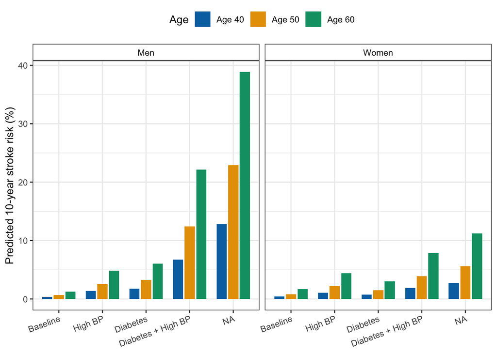

```r
plot_df <- risk_table %>%
  pivot_longer(
    cols = starts_with("Age"),
    names_to = "age",
    values_to = "risk") %>%
  mutate(
    scenario = factor(
      scenario,
      levels = c("Baseline", "High BP", "Diabetes",
                 "Diabetes + High BP", "Smoker")),
    age = factor(age, levels = c("Age 40", "Age 50", "Age 60")))

ggplot(plot_df, aes(x = scenario, y = risk, fill = age)) +
  geom_col(position = position_dodge(width = 0.8), width = 0.7) +
  facet_wrap(~ sex) +
    scale_fill_manual(values = c(
    "Age 40" = "#0072B2",
    "Age 50" = "#E69F00",
    "Age 60" = "#009E73")) +
  labs(
    x = NULL,
    y = "Predicted 10-year stroke risk (%)",
    fill = "Age") +
  theme_bw() +
  theme(
    legend.position = "top",
    strip.background = element_rect(fill = "white"),
    axis.text.x = element_text(angle = 20, hjust = 1))
```

## Secondary Analysis

“how much change there is in the risk factors over in the 3 periods of data collection”

```r
# # change across periods
# rf_change <- fmhst_filt %>%
#   group_by(SEX) %>%
#   summarise(
#     # SYSBP
#     SYSBP_p1_med = median(SYSBP_PERIOD1, na.rm = TRUE),
#     SYSBP_p2_med = median(SYSBP_PERIOD2, na.rm = TRUE),
#     SYSBP_p3_med = median(SYSBP_PERIOD3, na.rm = TRUE),
#     SYSBP_change_abs = SYSBP_p3_med - SYSBP_p1_med,
#     SYSBP_change_pct = (SYSBP_change_abs / SYSBP_p1_med) * 100,
#
#     # BMI
#   )
```